# Exploratory Data Analysis (EDA)

**Internship Project**

This notebook presents an Exploratory Data Analysis performed to understand the dataset, identify trends and patterns, test assumptions using statistics and visualizations, and detect potential data quality issues.

```python
import pandas as pd
import numpy as np
import matplotlib.pyplot as plt
import seaborn as sns

%matplotlib inline
```

```python
df = pd.read_csv("superstore.csv")
df.head()
```

|  | Category | City | Country | Customer.ID | Customer.Name | Discount | Market | 记录数 | Order.Date | Order.ID | ... | Sales | Segment | Ship.Date | Ship.Mode | Shipping.Cost | State | Sub.Category | Year | Market2 | weeknum |
| --- | --- | --- | --- | --- | --- | --- | --- | --- | --- | --- | --- | --- | --- | --- | --- | --- | --- | --- | --- | --- | --- |
| 0 | Office Supplies | Los Angeles | United States | LS-172304 | Lycoris Saunders | 0.0 | US | 1 | 2011-01-07 00:00:00.000 | CA-2011-130813 | ... | 19 | Consumer | 2011-01-09 00:00:00.000 | Second Class | 4.37 | California | Paper | 2011 | North America | 2 |
| 1 | Office Supplies | Los Angeles | United States | MV-174854 | Mark Van Huff | 0.0 | US | 1 | 2011-01-21 00:00:00.000 | CA-2011-148614 | ... | 19 | Consumer | 2011-01-26 00:00:00.000 | Standard Class | 0.94 | California | Paper | 2011 | North America | 4 |
| 2 | Office Supplies | Los Angeles | United States | CS-121304 | Chad Sievert | 0.0 | US | 1 | 2011-08-05 00:00:00.000 | CA-2011-118962 | ... | 21 | Consumer | 2011-08-09 00:00:00.000 | Standard Class | 1.81 | California | Paper | 2011 | North America | 32 |
| 3 | Office Supplies | Los Angeles | United States | CS-121304 | Chad Sievert | 0.0 | US | 1 | 2011-08-05 00:00:00.000 | CA-2011-118962 | ... | 111 | Consumer | 2011-08-09 00:00:00.000 | Standard Class | 4.59 | California | Paper | 2011 | North America | 32 |
| 4 | Office Supplies | Los Angeles | United States | AP-109154 | Arthur Prichep | 0.0 | US | 1 | 2011-09-29 00:00:00.000 | CA-2011-146969 | ... | 6 | Consumer | 2011-10-03 00:00:00.000 | Standard Class | 1.32 | California | Paper | 2011 | North America | 40 |

5 rows × 27 columns

```python
df.shape
```

```
(51290, 27)
```

```python
df.info()
```

```
<class 'pandas.core.frame.DataFrame'>
RangeIndex: 51290 entries, 0 to 51289
Data columns (total 27 columns):
 #   Column          Non-Null Count  Dtype
---  ------          --------------  -----
 0   Category        51290 non-null  object
 1   City            51290 non-null  object
 2   Country         51290 non-null  object
 3   Customer.ID     51290 non-null  object
 4   Customer.Name   51290 non-null  object
 5   Discount        51290 non-null  float64
 6   Market          51290 non-null  object
 7   记录数             51290 non-null  int64
 8   Order.Date      51290 non-null  object
 9   Order.ID        51290 non-null  object
```

[output cut: 19 more lines]

```python
df.describe()
```

|  | Discount | 记录数 | Profit | Quantity | Row.ID | Sales | Shipping.Cost | Year | weeknum |
| --- | --- | --- | --- | --- | --- | --- | --- | --- | --- |
| count | 51290.000000 | 51290.0 | 51290.000000 | 51290.000000 | 51290.00000 | 51290.000000 | 51290.000000 | 51290.000000 | 51290.000000 |
| mean | 0.142908 | 1.0 | 28.610982 | 3.476545 | 25645.50000 | 246.498440 | 26.375818 | 2012.777208 | 31.287112 |
| std | 0.212280 | 0.0 | 174.340972 | 2.278766 | 14806.29199 | 487.567175 | 57.296810 | 1.098931 | 14.429795 |
| min | 0.000000 | 1.0 | -6599.978000 | 1.000000 | 1.00000 | 0.000000 | 0.002000 | 2011.000000 | 1.000000 |
| 25% | 0.000000 | 1.0 | 0.000000 | 2.000000 | 12823.25000 | 31.000000 | 2.610000 | 2012.000000 | 20.000000 |
| 50% | 0.000000 | 1.0 | 9.240000 | 3.000000 | 25645.50000 | 85.000000 | 7.790000 | 2013.000000 | 33.000000 |
| 75% | 0.200000 | 1.0 | 36.810000 | 5.000000 | 38467.75000 | 251.000000 | 24.450000 | 2014.000000 | 44.000000 |
| max | 0.850000 | 1.0 | 8399.976000 | 14.000000 | 51290.00000 | 22638.000000 | 933.570000 | 2014.000000 | 53.000000 |

## Dataset Overview

The dataset was explored to understand its structure, including the number of observations, variables, and data types. Initial inspection helped identify numerical and categorical features, as well as potential missing values.

```python
df.isnull().sum()
```

```
Category          0
City              0
Country           0
Customer.ID       0
Customer.Name     0
Discount          0
Market            0
记录数               0
Order.Date        0
Order.ID          0
Order.Priority    0
Product.ID        0
Product.Name      0
Profit            0
Quantity          0
Region            0
Row.ID            0
Sales             0
Segment           0
Ship.Date         0
Ship.Mode         0
Shipping.Cost     0
State             0
Sub.Category      0
Year              0
Market2           0
weeknum           0
dtype: int64
```

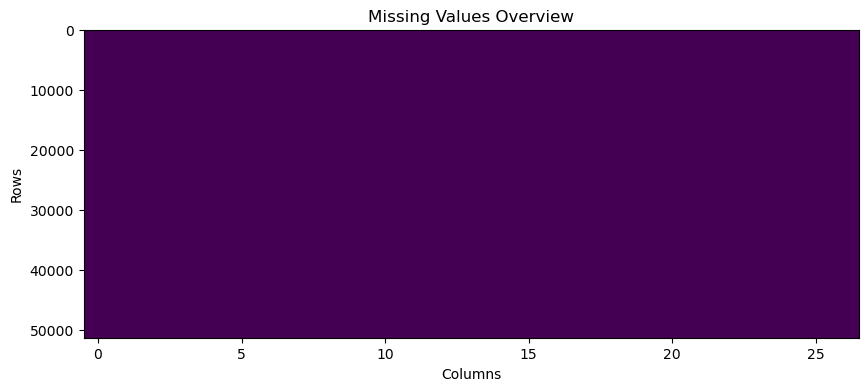

```python
import matplotlib.pyplot as plt
plt.figure(figsize=(10, 4))
plt.imshow(df.isnull(), aspect='auto')
plt.title("Missing Values Overview")
plt.xlabel("Columns")
plt.ylabel("Rows")
plt.show()
```

```python
df.duplicated().sum()
```

```
np.int64(0)
```

## Data quality Assessment

Data quality checks were conducted to identify missing values and duplicate records. These checks help highlight potential issues that may require data cleaning before further analysis.

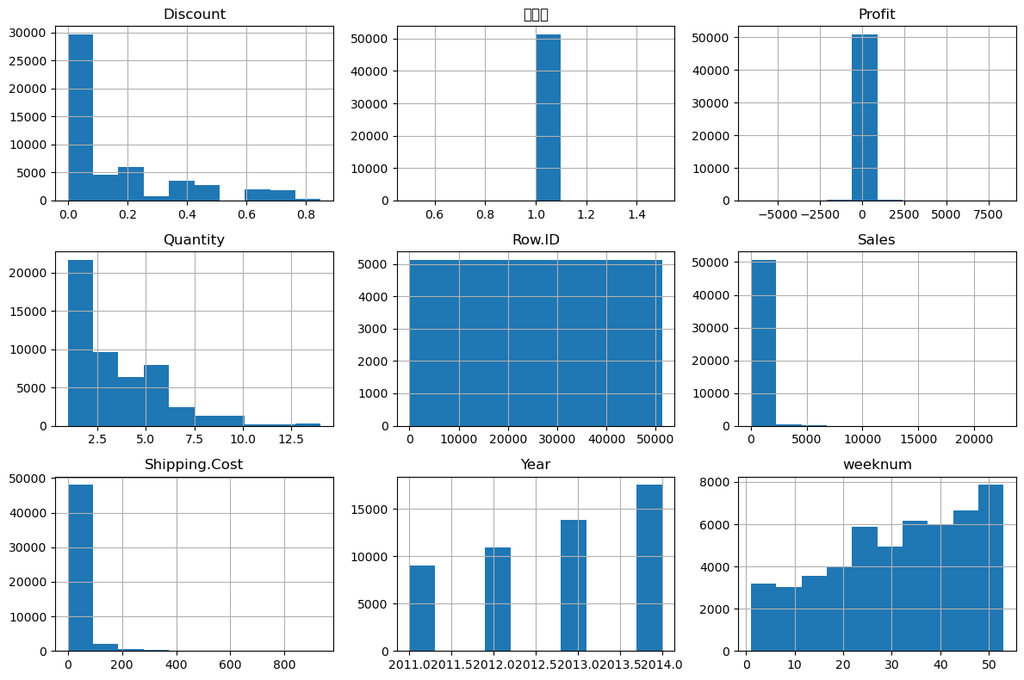

```python
df.hist(figsize=(12, 8))
plt.tight_layout()
plt.show()
```

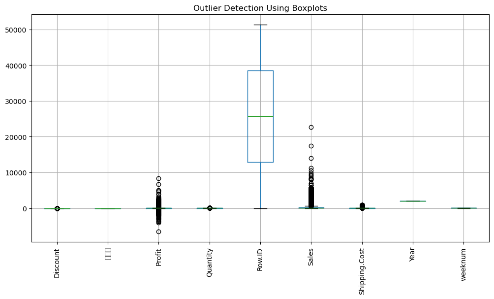

```python
plt.figure(figsize=(12, 6))
df.select_dtypes(include='number').boxplot(rot=90)
plt.title("Outlier Detection Using Boxplots")
plt.show()
```